# Homework 07

**Question 1**  
a)

```r
data <- read.csv("data/saheart.csv")
data$famhist <- ifelse(data$famhist == "Present", 2, 1)
X <- as.matrix(data[, !names(data) %in% "chd"])
y <- data$chd

n <- nrow(X)
K <- length(unique(y))

priors <- prop.table(table(y))
priors
```

```
y
        0         1
0.6536797 0.3463203
```

```r
mu <- aggregate(X, by = list(chd = y), FUN = mean)
mu
```

```
  chd      sbp  tobacco      ldl adiposity  famhist    typea  obesity  alcohol
1   0 135.4603 2.634735 4.344238  23.96911 1.317881 52.36755 25.73745 15.93136
2   1 143.7375 5.524875 5.487938  28.12025 1.600000 54.49375 26.62294 19.14525
       age
1 38.85430
2 50.29375
```

```r
S <- matrix(0, ncol(X), ncol(X))

for (k in unique(y)) {
  Xk <- X[y == k, , drop = FALSE]
  S <- S + (nrow(Xk) - 1) * cov(Xk)
}

S <- S / (n - K)
S
```

```
                  sbp    tobacco         ldl  adiposity    famhist        typea
sbp       405.4347786 14.5851882  4.58124834 49.1643582 0.33698819 -15.58772153
tobacco    14.5851882 19.2425564  0.76320271  7.5381093 0.01582050  -2.05730592
ldl         4.5812483  0.7632027  4.00058129  6.0326970 0.09185024   0.34459233
adiposity  49.1643582  7.5381093  6.03269701 56.7528931 0.43280832  -5.30956633
famhist     0.3369882  0.0158205  0.09185024  0.4328083 0.22583357   0.08112007
typea     -15.5877215 -2.0573059  0.34459233 -5.3095663 0.08112007  95.56564291
obesity    18.9388430  1.8334506  2.66005159 22.7078852 0.18402776   2.64006728
alcohol    64.4003517 20.5170451 -2.53290675 16.1190253 0.76846885   7.96003164
age        95.1338895 22.7654113  6.47892049 60.5086715 0.99736251 -20.27833492
             obesity     alcohol         age
sbp       18.9388430  64.4003517  95.1338895
tobacco    1.8334506  20.5170451  22.7654113
ldl        2.6600516  -2.5329068   6.4789205
adiposity 22.7078852  16.1190253  60.5086715
famhist    0.1840278   0.7684688   0.9973625
typea      2.6400673   7.9600316 -20.2783349
obesity   17.6154236   4.6893563  15.6969995
alcohol    4.6893563 598.2766133  27.8859413
age       15.6969995  27.8859413 184.1321373
```

The prior probabilities are estimated using the proportions of observations in each class. The class means are calculated by averaging the nine predictors within each class.

```r
dim(X)
```

```
[1] 462   9
```

```r
dim(S)
```

```
[1] 9 9
```

```r
dim(mu)
```

```
[1]  2 10
```

```r
length(y)
```

```
[1] 462
```

```r
means <- as.matrix(mu[, -1])
S_inv <- solve(S)

scores <- matrix(0, n, K)
for (k in 1:K) {
  m <- as.numeric(means[k, ])

  term1 <- X %*% S_inv %*% m
  term2 <- 0.5 * as.numeric(t(m) %*% S_inv %*% m)

  scores[, k] <- as.numeric(term1) - term2 + log(priors[k])
}

pred <- max.col(scores) - 1
confusion_manual <- table(Observed = y, Predicted = pred)
confusion_manual
```

```
        Predicted
Observed   0   1
       0 258  44
       1  73  87
```

The predictor matrix has dimensions $462 \times 9$, the pooled covariance matrix is $9 \times 9$, and the class mean matrix is $2 \times 9$. Therefore, the dimensions are consistent.

```r
library(MASS)
model <- lda(x = X, grouping = as.factor(y),
             prior = as.numeric(priors))

pred_lda <- predict(model, X)$class

confusion_lda <- table(Observed = y, Predicted = pred_lda)
confusion_lda
```

```
        Predicted
Observed   0   1
       0 258  44
       1  73  87
```

```r
all(confusion_manual == confusion_lda)
```

```
[1] TRUE
```

The confusion matrix from `MASS::lda()` is identical to the one obtained in part (b). Both methods correctly classify 345 out of 462 observations, giving a training accuracy of approximately 74.68%. The comparison returns `TRUE`, confirming that the results match.

**Question 2**  
a)

```r
library(MASS)
train <- read.csv("data/zip-train.csv.gz", header = FALSE)
test <- read.csv("data/zip-test.csv.gz", header = FALSE)
y_train <- as.factor(train[[1]])
y_test <- as.factor(test[[1]])

X_train <- train[, -1]
X_test <- test[, -1]

variances <- apply(X_train, 2, var)
top40 <- order(variances, decreasing = TRUE)[1:40]

model40 <- qda(x = X_train[, top40],
               grouping = y_train)

pred40 <- predict(model40, X_test[, top40])$class

conf40 <- table(Observed = y_test, Predicted = pred40)
conf40
```

```
        Predicted
Observed   0   1   2   3   4   5   6   7   8   9
       0 319   0  24   6   2   2   1   0   5   0
       1   0 238   5   0  11   0   7   0   3   0
       2   8   0 168   8   8   3   0   0   3   0
       3   5   0   4 128   0  14   0   0  15   0
       4   0   2  13   1 150   1   0   1   7  25
       5  12   0   3   5   1 131   0   0   6   2
       6   0   0   8   0   1   8 148   0   5   0
       7   1   0   6   1   6   0   0 124   2   7
       8   1   0  10  12   3   2   0   0 137   1
       9   0   0   1   2   7   1   1   4   9 152
```

```r
error40 <- mean(pred40 != y_test)
error40
```

```
[1] 0.1554559
```

We selected the 40 predictors with the largest marginal variances in the training data and fitted a QDA model. The test misclassification rate is 0.1555 (15.55%), corresponding to a test accuracy of 84.45%.

2. Yes, the method works. Reducing the number of predictors from 256 to 40 helps avoid singular within-class covariance matrices, allowing QDA to be fitted successfully. However, selecting predictors based on variance does not necessarily select the most informative features for classification.

```r
top10 <- order(variances, decreasing = TRUE)[1:10]
model10 <- qda(x = X_train[, top10],
               grouping = y_train)

pred10 <- predict(model10, X_test[, top10])$class
conf10 <- table(Observed = y_test, Predicted = pred10)
conf10
```

```
        Predicted
Observed   0   1   2   3   4   5   6   7   8   9
       0 298   0  11   1   1  16  28   4   0   0
       1   0 241  10   0   3   1   1   0   2   6
       2  19   2  95  14  14   3  22  21   5   3
       3   5   0   6 103   3  42   0   0   7   0
       4   1   5  14   0  95   2   4  15  17  47
       5  15   0   6  25   4  96   4   2   8   0
       6  41   0  15   4   0  18  78   7   5   2
       7   4   1   6   0   6   0   1 122   0   7
       8   1   2  11  36  12  11   4   1  74  14
       9   0   2   9   2  20   0   0  16  10 118
```

```r
error10 <- mean(pred10 != y_test)
error10
```

```
[1] 0.3423019
```

```r
error40
```

```
[1] 0.1554559
```

```r
error10
```

```
[1] 0.3423019
```

Using the 10 predictors with the largest marginal variances, the test misclassification rate is 34.23%, which is higher than the 40-predictor model’s rate of 15.55%. This suggests that reducing the number of predictors too much removes useful information for distinguishing digits. Although fewer predictors make covariance estimation easier, the loss of information leads to worse classification performance.

**Question 3**

```r
library(MASS)

set.seed(43257)

rhos <- c(0, 0.2, 0.4, 0.6, 0.8, 0.9)

generate_data <- function(rho, n) {
  S1 <- diag(10)
  S2 <- diag(10)

  S1[1, 2] <- S1[2, 1] <- rho
  S2[1, 2] <- S2[2, 1] <- -rho

  X1 <- mvrnorm(n, c(-1, 0, rep(0, 8)), S1)
  X2 <- mvrnorm(n, c(1, 0, rep(0, 8)), S2)

  list(X = rbind(X1, X2),
       y = factor(rep(1:2, each = n)))
}

run_sim <- function(rho) {
  train <- generate_data(rho, 100)
  test <- generate_data(rho, 1000)

  lda_fit <- lda(train$X, train$y, prior = c(0.5, 0.5))
  qda_fit <- qda(train$X, train$y, prior = c(0.5, 0.5))

  lda_pred <- predict(lda_fit, test$X)$class
  qda_pred <- predict(qda_fit, test$X)$class

  c(LDA = mean(lda_pred != test$y),
    QDA = mean(qda_pred != test$y))
}

results_a <- t(sapply(rhos, run_sim))
rownames(results_a) <- rhos
round(results_a, 4)
```

```
       LDA    QDA
0   0.1975 0.2170
0.2 0.1685 0.1885
0.4 0.1645 0.1965
0.6 0.1585 0.1700
0.8 0.1710 0.1555
0.9 0.1535 0.1085
```

The results show that LDA has lower test error for smaller values of $\rho$, while QDA performs better at $\rho=0.8$ and $\rho=0.9$. This suggests that QDA benefits from modeling different covariance structures when the correlation becomes stronger. b)

```r
set.seed(43258)

avg_errors <- matrix(0, length(rhos), 2)
colnames(avg_errors) <- c("LDA", "QDA")

for (i in seq_along(rhos)) {
  errors <- replicate(50, run_sim(rhos[i]))
  avg_errors[i, ] <- rowMeans(errors)
}

results_b <- data.frame(rho = rhos, avg_errors)
print(results_b)
```

```
  rho     LDA     QDA
1 0.0 0.16959 0.19906
2 0.2 0.16879 0.19519
3 0.4 0.16937 0.18933
4 0.6 0.16995 0.17447
5 0.8 0.16701 0.13609
6 0.9 0.16812 0.10083
```

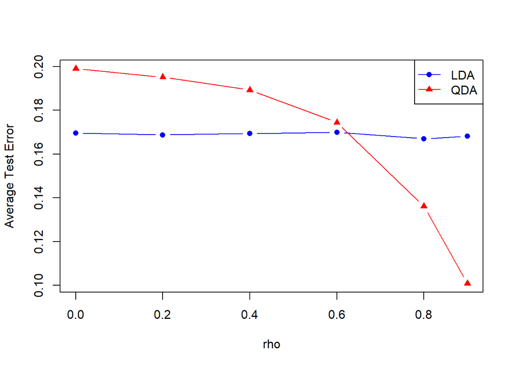

```r
# Plot
plot(rhos, avg_errors[, "LDA"],
     type = "b", col = "blue", pch = 16,
     ylim = range(avg_errors),
     xlab = "rho", ylab = "Average Test Error")

lines(rhos, avg_errors[, "QDA"],
      type = "b", col = "red", pch = 17)

legend("topright",
       legend = c("LDA", "QDA"),
       col = c("blue", "red"),
       pch = c(16, 17), lty = 1)
```

After 50 repetitions, the average test error of LDA remains nearly constant at around 0.17, while QDA’s average test error decreases as $\rho$ increases. LDA performs better when $\rho$ is small, but QDA outperforms LDA at larger values of $\rho$.

3. At small values of $\rho$, LDA performs better because the two classes have similar covariance matrices. LDA estimates fewer parameters, resulting in lower estimation variance.

As $\rho$ increases, the covariance matrices become more different. QDA can model these differences, reducing bias and improving classification accuracy. In contrast, LDA assumes a common covariance matrix, so its performance does not improve much.

The eight noise covariates provide no information about the class labels, but they increase the number of parameters to estimate. This increases estimation variance and may reduce accuracy, especially for QDA.

**Question 4**

[interactive chart not shown]

Using random seed 43259, we reserved 20% of the SAheart observations as a stratified test set and compared LDA/QDA-based candidate models using stratified 5-fold cross-validation on the training data.

PCA with five components followed by LDA achieved the lowest mean cross-validation misclassification rate of 27.92%. After refitting on the complete training set, the selected model achieved a held-out test misclassification rate of 25.81% (24 errors among 93 observations).

The results suggest that moderate dimensionality reduction can improve predictive performance. However, differences among some candidate models are relatively small, and the test error is subject to sampling variability.

# LDA/QDA Classification Report Skill

## Invocation

Use this skill only when the user explicitly provides or references this SKILL.md and asks to apply it. Do not auto-activate it. Dataset, response column, predictor columns, and any coding rules must be supplied in the invocation, never assumed here.

## Objective

Find a strong classifier using only LDA, QDA, or their probability-weighted blends. Produce a readable statistical report occupying at most one printed page, containing a figure, a table, and numerical model results. Ensure the evaluation is reproducible and free of test-set leakage.

## Required inputs

- Dataset or training data file, response name, predictor names, and any encoding instructions.
- Optional random seed; use and report a fixed seed if none supplied.
- Identify classification labels, missing values, and sample size. Explain exclusions.

## Analysis protocol

1. Before inspecting model results, reserve a stratified 20% test set; use 80% for training. Do not use the held-out test set for model choice, preprocessing design, or tuning.
2. On the training portion, create one fixed stratified 5-fold cross-validation split and reuse the exact folds for every candidate. Use misclassification rate as the primary selection criterion; show the mean fold error. If classes are too small for five folds, use fewer stratified folds and say why.
3. Compare at least ordinary LDA and ordinary QDA, with empirical class priors estimated from each fitting subset. Optionally consider PCA followed by LDA/QDA, using a few prespecified component counts, and/or LDA/QDA probability blends with prespecified weights. Never use classifiers other than LDA, QDA, or their combinations.
4. Within each fold, learn all preprocessing (imputation, scaling, PCA, etc.) on that fold’s training observations only. Apply fitted transformations unchanged to its validation fold. Fit each classifier only on the fold’s training subset. For a blend, combine aligned class-probability columns before taking the largest probability.
5. Record failures such as singular covariance matrices. Do not silently discard failed folds or leak information across folds. Flag invalid candidate settings and explain why. Select the candidate with the smallest mean CV misclassification rate; break ties in favor of the simpler model.
6. Refit the selected candidate and its preprocessing from scratch using the complete training portion. Predict the untouched test set exactly once. Report its misclassification rate and the number of test errors / test cases. Do not change models or settings after viewing this result.
7. Check factor levels and probability column ordering, dimensions, class counts, missing values, and whether every figure/table is consistent with computed results.

## One-page report layout

- **Title and data:** response, number of predictors, training/test sizes, seed, and split/CV design.
- **Methods:** brief candidate model list, preprocessing choices, and primary metric.
- **Table:** candidate models and their mean 5-fold CV misclassification rates; mark the selected candidate. Note any fitting failures.
- **Figure:** a compact, legible comparison plot of CV misclassification rates, with labeled axes and a legend if needed.
- **Results:** selected model and settings, CV error, held-out test error, and count misclassified / test sample size.
- **Interpretation and limitations:** 2-4 concise sentences on comparative results, sampling variability, assumptions, and any class imbalance or instability.

Keep the report within one printed page at ordinary readable font size. Put code and implementation details outside the one-page report when requested. Never invent numerical results; if data are unavailable, request them and provide no fabricated table or figure. After generating the report, inspect it for correctness and layout.